# GroupProject

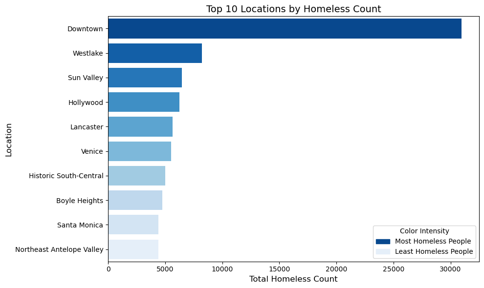

```python
# Define the color palette manually
colors = sns.color_palette("Blues_r", len(top_locations))

# Plot
plt.figure(figsize=(10, 6))
barplot = sns.barplot(
    x='tothomeless_count',
    y='name',
    data=top_locations,
    hue=None,  # Ensure no hue is used
    legend=False  # Avoid Seaborn's automatic legend
)

# Manually set colors for each bar
for bar, color in zip(barplot.patches, colors):
    bar.set_facecolor(color)

# Add title and labels
plt.title('Top 10 Locations by Homeless Count', fontsize=14)
plt.xlabel('Total Homeless Count', fontsize=12)
plt.ylabel('Location', fontsize=12)

# Add custom legend
dark_blue_patch = mpatches.Patch(color=colors[0], label='Most Homeless People')
light_blue_patch = mpatches.Patch(color=colors[-1], label='Least Homeless People')
plt.legend(handles=[dark_blue_patch, light_blue_patch], title="Color Intensity")

# Final layout adjustments
plt.tight_layout()
plt.show()
```

This bar chart highlights the top 10 Los Angeles locations by homeless count, with Downtown clearly standing out as having the highest homeless population, followed by Westlake and Sun Valley. In contrast, Northeast Antelope Valley has the lowest count among the top 10. The reversed color intensity (dark blue for the highest count and light blue for the lowest) visually emphasizes the variation between locations. This graph directly supports the research question by identifying neighborhoods that consistently receive the highest levels of homeless response services, helping to pinpoint areas of significant need and resource allocation.

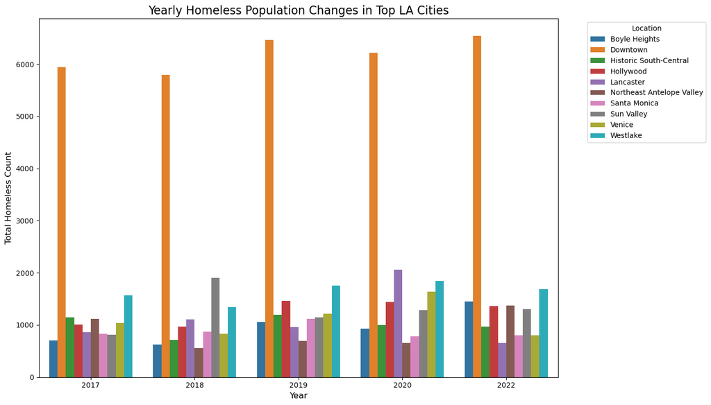

```python
# Bar Chart of Yearly Changes in Homeless Population for Cities with the Highest Homeless Counts
plt.figure(figsize=(14, 8))
sns.barplot(
    x='year',
    y='tothomeless_count',
    hue='name',
    data=location_year_data[location_year_data['name'].isin(top_locations['name'])]
)
plt.title('Yearly Homeless Population Changes in Top LA Cities', fontsize=16)
plt.xlabel('Year', fontsize=12)
plt.ylabel('Total Homeless Count', fontsize=12)
plt.legend(title='Location', bbox_to_anchor=(1.05, 1), loc='upper left')
plt.tight_layout()
plt.show()
```

```python
import folium
from folium.plugins import HeatMap

# Drop rows with missing latitude, longitude, or homeless count
heat_data = data1[['latitude', 'longitude', 'tothomeless_count']].dropna()

# Create a map centered on Los Angeles
heatmap = folium.Map(location=[34.0522, -118.2437], zoom_start=10)

# Add HeatMap layer
HeatMap(heat_data[['latitude', 'longitude', 'tothomeless_count']].values.tolist(), radius=15).add_to(heatmap)

# Display the heatmap
heatmap
```

Make this Notebook Trusted to load map: File -> Trust Notebook

[interactive chart not shown]

This heatmap visualizes the distribution of homeless populations across Los Angeles neighborhoods, with more intense colors (yellow and green) indicating higher homeless counts. Downtown Los Angeles emerges as a clear hotspot, followed by nearby areas such as Westlake and Hollywood, while outlying regions like Northeast Antelope Valley show minimal activity. This visualization directly supports the research question by geographically highlighting neighborhoods that consistently receive the highest and lowest levels of homeless response services, providing a spatial perspective to complement numerical analyses.

```python
# Save the heatmap to an HTML file
heatmap.save("homeless_population_heatmap.html")
print("Heatmap saved as 'homeless_population_heatmap.html'")
```

```
Heatmap saved as 'homeless_population_heatmap.html'
```

```python
# Load the dataset
data_path = "data1.csv"  # Replace with your file path
data = pd.read_csv(data_path)

# Drop rows with missing latitude or longitude values
data = data.dropna(subset=['latitude', 'longitude'])

# Create a map centered on Los Angeles
map_with_cities = folium.Map(location=[34.0522, -118.2437], zoom_start=10)

# Group data by city ('name') and add markers for each city
for city, group in data.groupby('name'):
    # Extract city latitude, longitude, and create a popup message with year and homeless count info
    latitude = group['latitude'].iloc[0]
    longitude = group['longitude'].iloc[0]
    popup_message = "<b>{}</b><br>".format(city)
    popup_message += "<br>".join(
        [f"Year: {row['year']}, Homeless Count: {row['tothomeless_count']}" for _, row in group.iterrows()]
    )

    # Add a marker to the map
    folium.Marker(
        location=[latitude, longitude],
        popup=folium.Popup(popup_message, max_width=300)
    ).add_to(map_with_cities)

# Let the map object be the last line to display it
map_with_cities
```

Make this Notebook Trusted to load map: File -> Trust Notebook

[interactive chart not shown]

This map displays markers representing different Los Angeles neighborhoods, with pop-ups showing yearly homeless counts from 2017 to 2022 for each location. The interactive feature allows users to explore specific neighborhoods and observe trends in homelessness over time. This visualization helps answer the research question by geographically pinpointing neighborhoods that consistently experience high or low levels of homelessness, providing a clear overview of how services might be allocated based on demand across various areas in LA.

```python
# Save the map as an HTML file
map_with_cities.save("cities_homeless_map.html")
print("Map saved as 'cities_homeless_map.html'")
```

```
Map saved as 'cities_homeless_map.html'
```